# UWWI Calls and News Articles

Sophie L.

2022-12-03

# Data preparation

Reading in datafiles:

```r
files_uwwi = c("../../uwwi_datasets/uwwi_dataset_interactions/uwwi_dataset_interactions_2020.csv",
               "../../uwwi_datasets/uwwi_dataset_interactions/uwwi_dataset_interactions_2021.csv",
               "../../uwwi_datasets/uwwi_dataset_interactions/uwwi_dataset_interactions_2022.csv")
uwwi = read_csv(files_uwwi, id = "path")
uwwi$date = as_date(uwwi$Interaction_CreateStamp)

files_news = fs::dir_ls(glob = "*Wisconsin*csv")
news_types = read_csv(files_news, id = "path")
news = read_csv("gnews_all_with_timestamp.csv")
newstypes = unique(news_types$path)
names(newstypes) = c("Drought", "ExtremeWeather", "FinancialCrisis", "Fire", "Flood", "Food", "Heat", "HousingCrisis", "Emergency")
news = left_join(news, news_types[,c("path", "title")], by = "title") %>%
  mutate(type = factor(path, levels = newstypes, labels = names(newstypes)),
         date = mdy(date_parsed)) %>%
  filter(!is.na(type)) %>%
  select(-path, -date_parsed)

news_by_date_and_type = news %>%
  group_by(date, type) %>%
  summarise(news = n()) %>%
  pivot_wider(names_from = type, values_from = news,
              values_fill = 0, names_prefix = "news_")
news_by_date_and_type = left_join(news_by_date_and_type,
                                  count(news, date, name = "news"),
                                  by = "date")

dat = full_join(count(uwwi, date, name = "calls"),
                news_by_date_and_type,
                by = "date")
newstypes = colnames(dat)[which(startsWith(colnames(dat), "news_"))]
dat$weekday = wday(dat$date, label = TRUE, week_start = 1)
# fill in dates with no news items as 0:
dat = mutate_at(dat, vars(starts_with("news")), ~ifelse(is.na(.), 0, .))
```

```r
kable_styling(kable(count(news, type), caption = "Number of Wisconsin Google News headlines by category"), full_width = FALSE)
```

Number of Wisconsin Google News headlines by category

| type | n |
| --- | --- |
| Drought | 78 |
| ExtremeWeather | 86 |
| FinancialCrisis | 77 |
| Fire | 57 |
| Flood | 85 |
| Food | 1 |
| Heat | 59 |
| HousingCrisis | 93 |
| Emergency | 53 |

```r
group_by(dat, weekday) %>%
  summarise(calls = sum(calls, na.rm = TRUE),
            news = sum(news, na.rm = TRUE)) %>%
  kable(caption = "Number of 2-1-1 calls and Google News headlines by weekday") %>%
  kable_styling(full_width = FALSE)
```

Number of 2-1-1 calls and Google News headlines by weekday

| weekday | calls | news |
| --- | --- | --- |
| Mo | 5417 | 119 |
| Di | 5432 | 97 |
| Mi | 5382 | 109 |
| Do | 5126 | 108 |
| Fr | 5008 | 96 |
| Sa | 3458 | 34 |
| So | 2919 | 26 |

Both news coverage and calls clearly differ by weekday (especially by weekday/weekend status), so the following analyses control for the role of day of the week. The following models are fixed-effects models with weekday as fixed effect.

There were only 20 news entries for 2020 and 68 for 2021 in the dataset. This may reflect a problem with the underlying dataset that should be addressed before drawing firm conclusions based on these analyses. Because 2020 and 2021 are so sparse, the following analyses use 2022 data only.

# Analyses

## Overall number of news headlines + overall number of calls

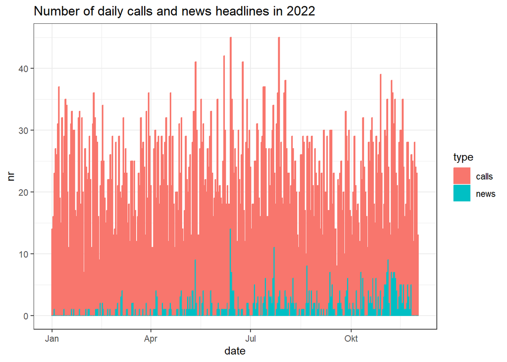

```r
filter(dat, year(date) == 2022) %>%
  select(-starts_with("news_")) %>%
  pivot_longer(c(-date, -weekday), names_to = "type", values_to = "nr") %>%
  ggplot(aes(x = date, y = nr, color = type, fill = type, group = type)) +
  geom_bar(stat = "identity") +
  ggtitle("Number of daily calls and news headlines in 2022") +
  scale_x_date(date_labels = "%b") +
  theme_bw()
```

### Lags 0-6

```r
model_allnews = felm(calls ~ news +
                       lag(news, 1) + lag(news, 2) + lag(news, 3) +
                       lag(news, 4) + lag(news, 5) + lag(news, 6) | weekday | 0,
                     data = filter(dat, year(date) == 2022))
summary(model_allnews)
```

```
##
## Call:
##    felm(formula = calls ~ news + lag(news, 1) + lag(news, 2) + lag(news,      3) + lag(news, 4) + lag(news, 5) + lag(news, 6) | weekday |      0, data = filter(dat, year(date) == 2022))
##
## Residuals:
##      Min       1Q   Median       3Q      Max
## -13.4457  -3.5942  -0.2652   3.3876  15.4965
##
## Coefficients:
##              Estimate Std. Error t value Pr(>|t|)
## news         -0.15492    0.16255  -0.953    0.341
## lag(news, 1) -0.09892    0.16853  -0.587    0.558
## lag(news, 2) -0.12341    0.16935  -0.729    0.467
## lag(news, 3) -0.10243    0.16974  -0.603    0.547
## lag(news, 4)  0.26311    0.16948   1.552    0.122
## lag(news, 5)  0.07917    0.16868   0.469    0.639
## lag(news, 6) -0.09866    0.16269  -0.606    0.545
##
## Residual standard error: 5.24 on 315 degrees of freedom
##   (6 Beobachtungen als fehlend gelöscht)
## Multiple R-squared(full model): 0.4081   Adjusted R-squared: 0.3837
## Multiple R-squared(proj model): 0.01836   Adjusted R-squared: -0.02215
## F-statistic(full model):16.71 on 13 and 315 DF, p-value: < 2.2e-16
## F-statistic(proj model): 0.8416 on 7 and 315 DF, p-value: 0.5535
```

The overall number of news headlines was not associated with the number of calls over the course of a week (= neither with calls on the same day nor on any of the following 6 days).

## Types of news headlines and overall calls

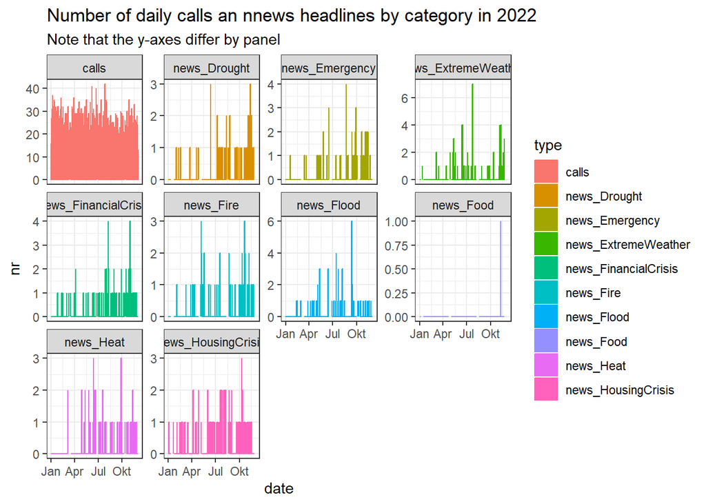

```r
filter(dat, year(date) == 2022) %>%
  select(-news) %>%
  pivot_longer(c(-date, -weekday), names_to = "type", values_to = "nr") %>%
  ggplot(aes(x = date, y = nr, color = type, fill = type)) +
  geom_bar(stat = "identity") +
  facet_wrap(~type, scales = "free_y") +
  ggtitle("Number of daily calls an nnews headlines by category in 2022",
          subtitle = "Note that the y-axes differ by panel") +
  scale_x_date(date_labels = "%b") +
  theme_bw()
```

### Lag 0

```r
formula_t0 = paste("calls ~ ",
                   paste(newstypes, collapse = " + "),
                   " | weekday | 0")
model_t0 = felm(as.formula(formula_t0),
                data = filter(dat, year(date) == 2022))
summary(model_t0)
```

```
##
## Call:
##    felm(formula = as.formula(formula_t0), data = filter(dat, year(date) ==      2022))
##
## Residuals:
##      Min       1Q   Median       3Q      Max
## -13.3421  -3.4107  -0.1618   3.2344  17.2992
##
## Coefficients:
##                      Estimate Std. Error t value Pr(>|t|)
## news_Flood            -0.6887     0.4912  -1.402   0.1619
## news_FinancialCrisis  -0.8158     0.5442  -1.499   0.1348
## news_HousingCrisis    -1.0697     0.5930  -1.804   0.0722 .
## news_Drought          -0.4424     0.6236  -0.709   0.4786
## news_Emergency        -0.7951     0.5967  -1.332   0.1837
## news_ExtremeWeather    0.1058     0.4072   0.260   0.7951
## news_Heat              0.9415     0.6350   1.483   0.1392
## news_Fire              0.1572     0.6377   0.247   0.8054
## news_Food              4.7016     5.3224   0.883   0.3777
## ---
## Signif. codes:  0 '***' 0.001 '**' 0.01 '*' 0.05 '.' 0.1 ' ' 1
##
## Residual standard error: 5.168 on 319 degrees of freedom
## Multiple R-squared(full model): 0.4256   Adjusted R-squared: 0.3986
## Multiple R-squared(proj model): 0.03988   Adjusted R-squared: -0.005262
## F-statistic(full model):15.76 on 15 and 319 DF, p-value: < 2.2e-16
## F-statistic(proj model): 1.472 on 9 and 319 DF, p-value: 0.157
```

None of the different types of news appears strongly associated with number of calls on the same day.

### Lag 1

```r
formula_t1 = paste("calls ~ ",
                   paste(newstypes, collapse = " + "),
                   "+",
                   paste0("lag(", newstypes, ")", collapse = " + "),
                   " | weekday | 0")
model_t1 = felm(as.formula(formula_t1),
                data = filter(dat, year(date) == 2022))
summary(model_t1)
```

```
##
## Call:
##    felm(formula = as.formula(formula_t1), data = filter(dat, year(date) ==      2022))
##
## Residuals:
##      Min       1Q   Median       3Q      Max
## -13.8638  -3.3686  -0.1055   3.2065  17.2501
##
## Coefficients:
##                            Estimate Std. Error t value Pr(>|t|)
## news_Flood                -0.789129   0.504554  -1.564   0.1188
## news_FinancialCrisis      -0.740471   0.557164  -1.329   0.1848
## news_HousingCrisis        -1.026853   0.602986  -1.703   0.0896 .
## news_Drought              -0.353402   0.655989  -0.539   0.5905
## news_Emergency            -0.785541   0.619597  -1.268   0.2058
## news_ExtremeWeather        0.346080   0.465796   0.743   0.4581
## news_Heat                  0.965798   0.666430   1.449   0.1483
## news_Fire                  0.224520   0.659630   0.340   0.7338
## news_Food                  6.356049   5.651401   1.125   0.2616
## lag(news_Flood)            0.282934   0.506843   0.558   0.5771
## lag(news_FinancialCrisis) -0.541976   0.556669  -0.974   0.3310
## lag(news_HousingCrisis)   -0.524341   0.608856  -0.861   0.3898
## lag(news_Drought)         -0.198336   0.655158  -0.303   0.7623
## lag(news_Emergency)        0.003557   0.623870   0.006   0.9955
## lag(news_ExtremeWeather)  -0.346227   0.449683  -0.770   0.4419
## lag(news_Heat)             0.132774   0.668785   0.199   0.8428
## lag(news_Fire)            -0.590685   0.668946  -0.883   0.3779
## lag(news_Food)            -1.505394   5.675485  -0.265   0.7910
## ---
## Signif. codes:  0 '***' 0.001 '**' 0.01 '*' 0.05 '.' 0.1 ' ' 1
##
## Residual standard error: 5.216 on 309 degrees of freedom
##   (1 Beobachtung als fehlend gelöscht)
## Multiple R-squared(full model): 0.4307   Adjusted R-squared: 0.3864
## Multiple R-squared(proj model): 0.05158   Adjusted R-squared: -0.02208
## F-statistic(full model):9.739 on 24 and 309 DF, p-value: < 2.2e-16
## F-statistic(proj model): 0.9336 on 18 and 309 DF, p-value: 0.538
```

The types of news also are not strongly associated with the number of calls on the next day.

### Lag 2

```r
formula_t2 = paste("calls ~ ",
                   paste(newstypes, collapse = " + "),
                   "+",
                   paste0("lag(", newstypes, ", 1)", collapse = " + "),
                   "+",
                   paste0("lag(", newstypes, ", 2)", collapse = " + "),
                   " | weekday | 0")
model_t2 = felm(as.formula(formula_t2),
                data = filter(dat, year(date) == 2022))
summary(model_t2)
```

```
##
## Call:
##    felm(formula = as.formula(formula_t2), data = filter(dat, year(date) ==      2022))
##
## Residuals:
##     Min      1Q  Median      3Q     Max
## -13.943  -3.639   0.000   3.038  16.790
##
## Coefficients:
##                               Estimate Std. Error t value Pr(>|t|)
## news_Flood                   -0.683004   0.513350  -1.330   0.1844
## news_FinancialCrisis         -0.654735   0.568963  -1.151   0.2508
## news_HousingCrisis           -1.024138   0.607105  -1.687   0.0927 .
## news_Drought                 -0.128099   0.676191  -0.189   0.8499
## news_Emergency               -0.809195   0.638894  -1.267   0.2063
## news_ExtremeWeather           0.293187   0.484405   0.605   0.5455
## news_Heat                     0.976962   0.696681   1.402   0.1619
## news_Fire                     0.471359   0.685517   0.688   0.4922
## news_Food                     7.093420   5.751827   1.233   0.2185
## lag(news_Flood, 1)            0.428318   0.517577   0.828   0.4086
## lag(news_FinancialCrisis, 1) -0.477072   0.566011  -0.843   0.4000
## lag(news_HousingCrisis, 1)   -0.482184   0.615948  -0.783   0.4343
## lag(news_Drought, 1)         -0.115399   0.682171  -0.169   0.8658
## lag(news_Emergency, 1)       -0.036261   0.647903  -0.056   0.9554
## lag(news_ExtremeWeather, 1)  -0.677394   0.499189  -1.357   0.1758
## lag(news_Heat, 1)             0.308581   0.705157   0.438   0.6620
## lag(news_Fire, 1)            -0.456063   0.689799  -0.661   0.5090
## lag(news_Food, 1)            -1.338070   5.990362  -0.223   0.8234
## lag(news_Flood, 2)           -0.510545   0.524006  -0.974   0.3307
## lag(news_FinancialCrisis, 2) -0.253881   0.570607  -0.445   0.6567
## lag(news_HousingCrisis, 2)    0.890189   0.617738   1.441   0.1506
## lag(news_Drought, 2)         -0.639916   0.663175  -0.965   0.3354
## lag(news_Emergency, 2)       -1.009212   0.644790  -1.565   0.1186
## lag(news_ExtremeWeather, 2)   0.510821   0.458960   1.113   0.2666
## lag(news_Heat, 2)             0.008157   0.689056   0.012   0.9906
## lag(news_Fire, 2)            -0.397549   0.676922  -0.587   0.5575
## lag(news_Food, 2)             2.852574   6.034104   0.473   0.6367
## ---
## Signif. codes:  0 '***' 0.001 '**' 0.01 '*' 0.05 '.' 0.1 ' ' 1
##
## Residual standard error: 5.239 on 299 degrees of freedom
##   (2 Beobachtungen als fehlend gelöscht)
## Multiple R-squared(full model): 0.4428   Adjusted R-squared: 0.3813
## Multiple R-squared(proj model): 0.07379   Adjusted R-squared: -0.02844
## F-statistic(full model):  7.2 on 33 and 299 DF, p-value: < 2.2e-16
## F-statistic(proj model): 0.8822 on 27 and 299 DF, p-value: 0.6379
```

The types of news also are not strongly associated with the number of calls on the next two days.

## Overall news headlines and types of calls

Not tackled yet because the files allowing us to link individual calls to the type of services that callers were referred to were still being created. They’re ready now, see [here](https://github.com/datakind/UWWi_DataDive_Dec22/tree/main/uwwi_datasets/uwwi_dataset_interactions).

## Types of news headlines and types of calls

Same as above.